# MEML_HW05_Soln

**Machine Learning for Mechanical Engineering**  
**Homework 05 - Solution**  
**Due Tuesday, 04/28/2020, 09:30 AM**

TA : Jong Hwan Lee  
Instructor: Prof. Seungchul Lee  
http://iai.postech.ac.kr/  
Industrial AI Lab at POSTECH

- For your handwritten solution, scan or take a picture of them.
- For your code, only .ipynb file will be graded.
  - Please write your NAME and student ID on your .ipynb files. ex) LeeJongHwan_20192176_HW05.ipynb
- Please compress all files to make a single .zip file
  - Please write your NAME and student ID on your .zip files. ex) LeeJongHwan_20192176_HW05.zip
  - Submit it to LMS
- Do not submit a printed version of your code. It will not be graded.

# Problem 1: Image Panorama with Regression

We want to demonstrate an image panorama as an example of linear regression. A panorama is any wide-angle view or representation of a physical space.

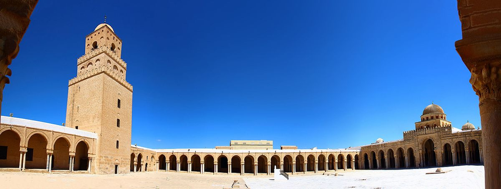

```python
%%html
<center><iframe src="https://www.youtube.com/embed/86rnwu3ZFbE?rel=0"
width="560" height="315" frameborder="0" allowfullscreen></iframe></center>
```

[video not shown]

- You need to install opencv module and download the images.
- opencv install
  - https://pypi.python.org/pypi/opencv-python
- Image download
  - https://www.dropbox.com/s/vlmp67zlq4mo0um/HW1.zip?dl=1

```python
# import library
import numpy as np
import matplotlib.pyplot as plt
import cv2
```

```python
# load images
imag1 = cv2.imread('./data_files/1.jpg')
imag1 = cv2.cvtColor(imag1, cv2.COLOR_BGR2RGB)
imag2 = cv2.imread('./data_files/2.jpg')
imag2 = cv2.cvtColor(imag2, cv2.COLOR_BGR2RGB)
imag3 = cv2.imread('./data_files/3.jpg')
imag3 = cv2.cvtColor(imag3, cv2.COLOR_BGR2RGB)
```

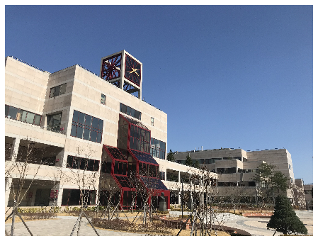

```python
plt.figure(figsize=(10, 6))
plt.imshow(imag1)
plt.axis('off')
plt.show()
```

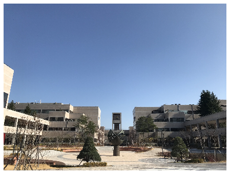

```python
plt.figure(figsize=(10, 6))
plt.imshow(imag2)
plt.axis('off')
plt.show()
```

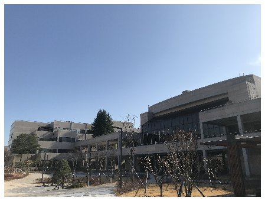

```python
plt.figure(figsize=(10, 6))
plt.imshow(imag3)
plt.axis('off')
plt.show()
```

**Panorama**

Here, we are explaining the basic concept of homography (i.e., perspective transformation).

- Any wide-angle view or representation of a physical space
- images with horizontally elongated fields of view
- idea: projecting images onto a common plane

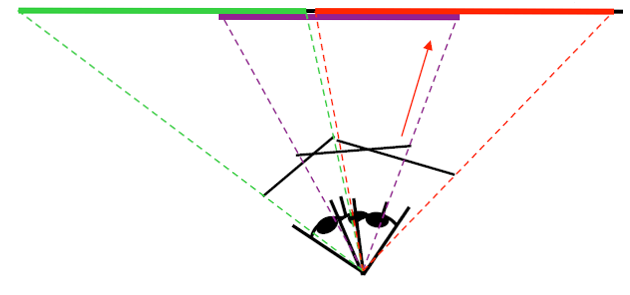

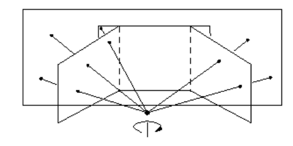

- Camera rotating about its center

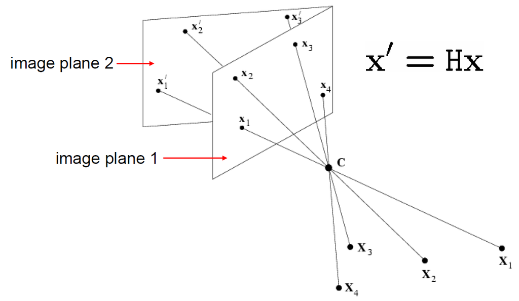

- Two image planes are related by a homography $H$

  Do not worry about a homography transformation. (out of this course's scope)

$$ \begin{bmatrix} x'\\y'\\1 \end{bmatrix} \sim \begin{bmatrix} \omega x'\\\omega y'\\\omega \end{bmatrix} = \begin{bmatrix} a & b & c \\ d & e & f \\ g & h & 1 \end{bmatrix} \begin{bmatrix} x\\y\\1 \end{bmatrix} $$

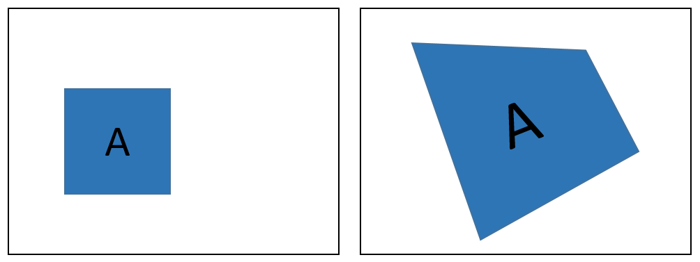

- For the advanced learner, watch the following online lecture by Prof. Aaron Bobick

```python
%%html
<center><iframe src="https://www.youtube.com/embed/pU4NorC7lb0?rel=0"
width="560" height="315" frameborder="0" allowfullscreen></iframe></center>
```

[video not shown]

## Find key points between two images

- Suppose these matching points are given.
  - We have manually found the matching points for you, although there is a technique to do this automatically.
- pos1 and pos2 are matching points between img01 and img02
- pos3 and pos4 are matching points between img02 and img03

```python
pos1 = np.array([[2121, 2117, 2749, 3095, 3032, 3375, 3677, 3876],
                 [1431, 2034, 2033, 1885, 2017, 2037, 1885, 2279]], dtype=np.int64)
pos2 = np.array([[188, 58, 828, 1203, 1121, 1437, 1717, 1817],
                 [1217, 1909, 1952, 1827, 1952, 1991, 1870, 2226]], dtype=np.int64)
pos3 = np.array([[2338, 2379, 2658, 2899, 2977, 3272, 2716, 2786],
                 [1948, 1874, 2000, 1837, 1964, 1966, 2143, 2317]], dtype=np.int64)
pos4 = np.array([[109, 178, 497, 795, 851, 1144, 534, 580],
                 [1907, 1828, 1988, 1834, 1971, 1993, 2145, 2333]], dtype=np.int64)
```

(a) Visualization of key points

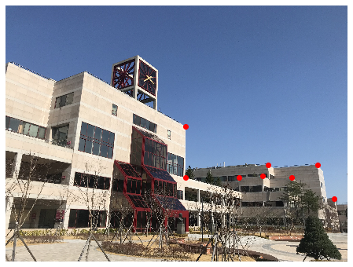

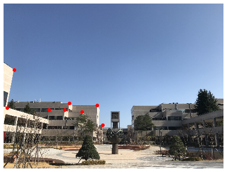

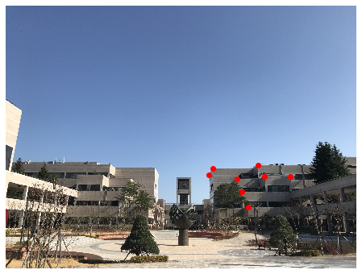

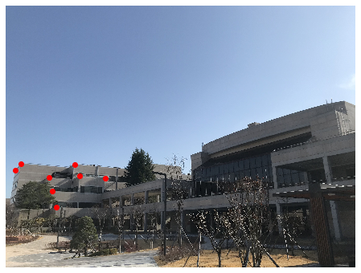

```python
## your code here

# Solution
plt.figure(figsize=(10, 6))
plt.imshow(imag1)
plt.plot(pos1[0,:], pos1[1,:], 'ro', 'linewidth', 1)
plt.axis('off')
plt.show()

plt.figure(figsize=(10, 6))
plt.imshow(imag2)
plt.plot(pos2[0,:], pos2[1,:], 'ro', 'linewidth', 1)
plt.axis('off')
plt.show()

plt.figure(figsize=(10, 6))
plt.imshow(imag2)
plt.plot(pos3[0,:], pos3[1,:], 'ro', 'linewidth', 1)
plt.axis('off')
plt.show()

plt.figure(figsize=(10, 6))
plt.imshow(imag3)
plt.plot(pos4[0,:], pos4[1,:], 'ro', 'linewidth', 1)
plt.axis('off')
plt.show()
```

**Estimation of homography H**

$$ X' = HX $$

where $ X $ and $X'$ are position vectors of key points, and $ H $ is a Perspective Transformation

**Goal: we need to estimate homography $H$ via matching points between two images**

$$\begin{bmatrix} x' \\ y' \\ 1 \end{bmatrix} \sim \begin{bmatrix} \omega x' \\ \omega y' \\ \omega \end{bmatrix} = \begin{bmatrix} \theta_{1} & \theta_{2} & \theta_{3} \\ \theta_{4} & \theta_{5} & \theta_{6} \\ \theta_{7} & \theta_{8} & 1 \end{bmatrix} \begin{bmatrix} x\\ y\\ 1 \end{bmatrix}$$

(b) Show the following equations from the above homography $H$

$$ \begin{align*} x' &= \frac{\theta_1 x+\theta_2 y+\theta_3}{\theta_7 x+\theta_8 y+1} \\ y' &= \frac{\theta_4 x+\theta_5 y+\theta_6}{\theta_7 x+\theta_8 y+1} \end{align*} $$
$$ \begin{align*} \theta_1 x+\theta_2 y+\theta_3 -\theta_7 x'x-\theta_8 x'y-x' &= 0 \\ \theta_4 x+\theta_5 y+\theta_6 -\theta_7 y'x-\theta_8 y'y-y' &= 0 \end{align*} $$

(c) For $m$ pairs of matching potins, show that a feature matrix $\Phi$ can be expressed as follows:

- $ \Phi $ is a feature matrix

$$ \Phi = \begin{bmatrix} x_{1} & y_{1} & 1 & 0 & 0 & 0 & -x'_{1}x_{1} & -x'_{1}y_{1}\\ 0 & 0 & 0 & x_{1} & y_{1} & 1 & -y'_{1}x_{1} & -y'_{1}y_{1}\\ \vdots &\vdots &\vdots &\vdots &\vdots &\vdots &\vdots &\vdots\\ x_{m} & y_{m} & 1 & 0 & 0 & 0 & -x'_{m}x_{m} & -x'_{m}y_{m}\\ 0 & 0 & 0 & x_{m} & y_{m} & 1 & -y'_{m}x_{m} & -y'_{m}y_{m}\end{bmatrix} $$

- $ \theta $ is a column vector for unknown parameters in a perspective transformation $H$

$$ \theta = \begin{bmatrix} \theta_{1} \\ \theta_{2} \\ \theta_{3} \\ \theta_{4} \\ \theta_{5} \\ \theta_{6} \\ \theta_{7} \\ \theta_{8} \end{bmatrix} $$

- $b$ is a column vector for corresponding positions in the base image

$$ b = \begin{bmatrix} x'_{1} \\ y'_{1} \\ x'_{2} \\ y'_{2} \\ \vdots \\ x'_{m} \\ y'_{m} \end{bmatrix} $$

- It ends up becoming a linear regression problem

$$ \min\limits_{\theta} \lVert \Phi\theta - b \rVert _2^2 $$$$ \theta^* = (\Phi^T\Phi)^{-1}\Phi^T b $$

(d) Perspective homography for image 1 and image 2

```python
## your code here

Phi01 = []
newpos01 = []
for i in range(8):
    temp1 = [[pos1[0,i], pos1[1,i], 1, 0, 0, 0, -pos2[0,i]*pos1[0,i], -pos2[0,i]*pos1[1,i]],
            [0, 0, 0, pos1[0,i], pos1[1,i], 1, -pos2[1,i]*pos1[0,i], -pos2[1,i]*pos1[1,i]]]
    temp2 = [[pos2[0,i]], [pos2[1,i]]]
    Phi01.append(temp1)
    newpos01.append(temp2)

Phi01 = np.concatenate(Phi01, axis=0)
newpos01 = np.concatenate(newpos01, axis=0).reshape(-1, 1)
Phi01 = np.asmatrix(Phi01)
newpos01 = np.asarray(newpos01)

## Solution
## Define perspective_theta using linear regression

perspective_theta = (Phi01.T*Phi01).I*Phi01.T*newpos01
perspective_theta = np.vstack([perspective_theta, [1]])
perspective_theta = perspective_theta.reshape(3, 3)
```

(e) Perspective homography for image 2 and image 3

```python
## your code here

Phi03 = []
newpos03 = []
for i in range(8):
    temp1 = [[pos4[0,i], pos4[1,i], 1, 0, 0, 0, -pos3[0,i]*pos4[0,i], -pos3[0,i]*pos4[1,i]],
            [0, 0, 0, pos4[0,i], pos4[1,i], 1, -pos3[1,i]*pos4[0,i], -pos3[1,i]*pos4[1,i]]]
    temp2 = [[pos3[0,i]], [pos3[1,i]]]
    Phi03.append(temp1)
    newpos03.append(temp2)

Phi03 = np.concatenate(Phi03, axis=0)
newpos03 = np.concatenate(newpos03, axis=0).reshape(-1, 1)
Phi03 = np.asmatrix(Phi03)
newpos03 = np.asarray(newpos03)

## Solution
## Define perspective_theta3 using linear regression
perspective_theta3 = (Phi03.T*Phi03).I*Phi03.T*newpos03
perspective_theta3 = np.vstack([perspective_theta3, [1]])
perspective_theta3 = perspective_theta3.reshape(3, 3)
```

## Image warping

- Again, do not worry about the image warping (outside lecture's scope)

```python
cv2.warpPerspective?
```

```python
## Apply image warping on image 1 & image 3 using cv2.warpPerspective function

## do translation to fit the warping image into a size of (18000, 6500) screen.
translation = np.matrix([[1, 0, 6000],
                         [0, 1, 2500],
                         [0, 0, 1]])

warpedImage = cv2.warpPerspective(imag1, translation*perspective_theta, (18000, 6500))
warpedImage3 = cv2.warpPerspective(imag3, translation*perspective_theta3, (18000, 6500))
```

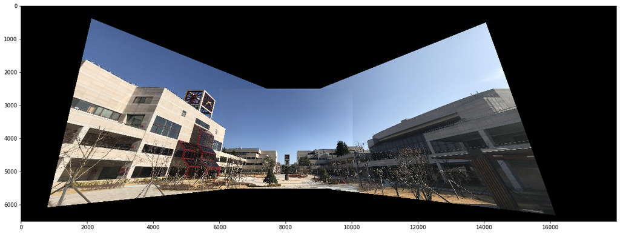

```python
screen = warpedImage.copy()
screen[screen==0] = warpedImage3[screen==0]
screen[2500:3024+2500,6000:4032+6000] = imag2

## Visualize panorama image
plt.figure(figsize=(20, 12))
plt.imshow(screen)
plt.show()
```

# Problem 2: Digit Classification

In this problem, we will try to classify handwritten digits. For the sake of simplicity, we simplify this digit classification problem into a binary classification between digit 0 and digit 1.

## Step 1. Load the data

| Data | Data dexcription |
| --- | --- |
| 0 | 1000 images (28×28 pixels) of handwritten digit 0 |
| 1 | 1000 images (28×28 pixels) of handwritten digit 1 |

[Download data](https://www.dropbox.com/s/aokbzv5cy2rbmzy/data.pkl?dl=1)

To read the files in Python, use the following code:

```python
import matplotlib.pyplot as plt
from six.moves import cPickle
data = cPickle.load(open('./data_files/data.pkl', 'rb'))
data0 = data['0']
data1 = data['1']
```

Here, we will load 1000 numbers of data from ‘0’ and ‘1’. To display the image use `plt.imshow(img)`.

Note: make sure you are reading the files correctly. Check by displaying the first few and the last few images in each class.

Note: calculations are more manageable if you go though and convert each of the pixels in $28\times28$ matrix to a binary value first.

(a) Display the few random images in each class.

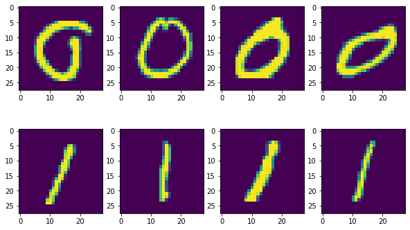

```python
## your code here

plt.figure(figsize=(10, 6))
plt.subplot(2,4,1), plt.imshow(data0[np.random.randint(0, 200)])
plt.subplot(2,4,2), plt.imshow(data0[np.random.randint(0, 200)])
plt.subplot(2,4,3), plt.imshow(data0[np.random.randint(800, 1000)])
plt.subplot(2,4,4), plt.imshow(data0[np.random.randint(800, 1000)])
plt.subplot(2,4,5), plt.imshow(data1[np.random.randint(0, 200)])
plt.subplot(2,4,6), plt.imshow(data1[np.random.randint(0, 200)])
plt.subplot(2,4,7), plt.imshow(data1[np.random.randint(800, 1000)])
plt.subplot(2,4,8), plt.imshow(data1[np.random.randint(800, 1000)])
plt.show()
```

(b) Convert each of the pixels in 28×28 matrix to a binary value.

```python
## your code here
##ex. data0 = data0 > 125

data0 = data0 > 125
data1 = data1 > 125
```

## Step 2. Extract features

Now we must select the own ‘features’ from image data to detect digit 0 and digit 1. Two features are recommended

(a) The total average pixels located at the center of the image (`img[10:20,10:20]`).

```python
## your code here
feature0_1 = np.sum(data0[:,10:20,10:20], axis=(1, 2)).reshape(-1, 1)/100
feature1_1 = np.sum(data1[:,10:20,10:20], axis=(1, 2)).reshape(-1, 1)/100
```

(b) The total average pixels over the entire location.

```python
## your code here
feature0_2 = np.sum(data0, axis=(1, 2)).reshape(-1, 1)/(28*28)
feature1_2 = np.sum(data1, axis=(1, 2)).reshape(-1, 1)/(28*28)
```

(c) Include the ones as our bias term.

$$\Phi(x) = \begin{bmatrix} 1 \\ \text{feature1}\\ \text{feature2} \end{bmatrix}$$

You should end up with a $2000\times3$ input matrix with the first $1000$ rows correspond to all of the ‘`data0`’ and the second 1000 rows correspond to the two features for all of the given ‘`data1`’. This matrix is matrix $\Phi$ which we learned in a class.

```python
## your code here
Theta0 = np.hstack([np.ones([feature0_1.shape[0], 1]), feature0_1, feature0_2])
Theta1 = np.hstack([np.ones([feature0_1.shape[0],1]), feature1_1, feature1_2])
Theta = np.vstack([Theta0, Theta1])

print(Theta.shape)
```

```
(2000, 3)
```

## Step 3. Plot the data

Plot the data to see if classes are separable. The expected plot is the following:

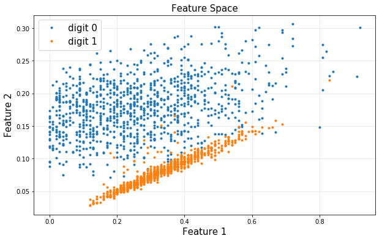

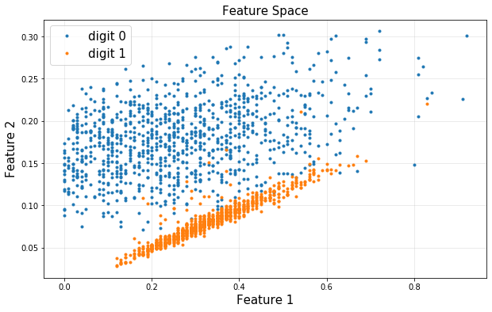

```python
## your code here
plt.figure(figsize=(10, 6))
plt.title('Feature Space', fontsize=15)
plt.plot(feature0_1, feature0_2, '.', label='digit 0')
plt.plot(feature1_1, feature1_2, '.', label='digit 1')
plt.grid(alpha=0.3)
plt.legend(fontsize=15)
plt.xlabel('Feature 1', fontsize=15)
plt.ylabel('Feature 2', fontsize=15)
plt.show()
```

# Problem 3: Digit classification with Perceptron

We would like to use the perceptron algorithm to classify digit 0 and digit 1 in the training set.

## Step 1. Initialization

You have to initialize $\omega$ . We usually set $\omega$ to a zero vector as an initial guess.

```python
## your code here
X0 = np.hstack([np.ones([data0.shape[0], 1]), feature0_1, feature0_2])
X1 = np.hstack([np.ones([data1.shape[0], 1]), feature1_1, feature1_2])
X = np.vstack([X0, X1])
X = np.asmatrix(X)

y = np.vstack([np.ones([1000, 1]), -np.ones([1000, 1])])
y = np.asmatrix(y)

# Initialize w
w = np.zeros([3, 1])
w = np.asmatrix(w)
```

## Step 2. Update $\omega$

We update $\omega$ when the prediction is wrong. The update rule is the following:

$$ \omega \leftarrow \omega + y \cdot x$$

For every $k$'s iteration, count and store how many predictions are wrong to see if your classifier converges to somewhere or not.

```python
## your code here
cp = []

n_iter = y.shape[0]
for k in range(100):
    cp.append(np.sum(np.sign(X*w) == y))
    for i in range(100):
        idx = np.random.randint(2000)
        if y[idx,0] != np.sign(X[idx,:]*w)[0,0]:
            w += y[idx,0]*X[idx,:].T
```

## Step 3. Plot the result

You are asked to plot two graphs. First, plot the number of wrong predictions with respect to every $k$'s iteration. The graph is expected as follows:

- Example

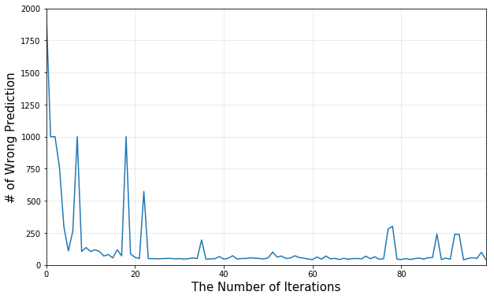

Second, plot the classifier (decision boundary). Note that the decision boundary is given:

$$\omega_1 x_1 + \omega_2x_2 + \omega_0 = 0$$

The expected graph is the following

- Example

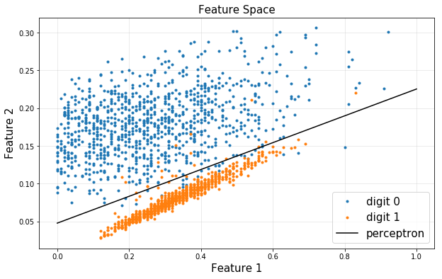

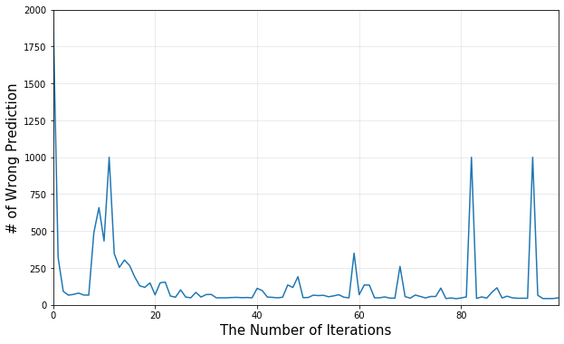

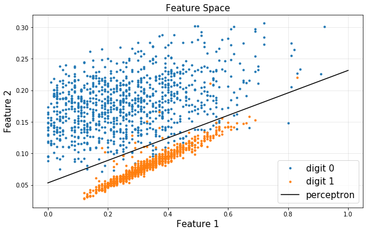

```python
## your code here
x1p = np.linspace(0,1).reshape(-1,1)
x2p = - w[1,0]/w[2,0]*x1p - w[0,0]/w[2,0]

plt.figure(figsize=(10, 6))
plt.plot(2000 - np.array(cp))
plt.xlabel('The Number of Iterations', fontsize=15)
plt.ylabel('# of Wrong Prediction', fontsize=15)
plt.axis([0, 99, 0, 2000])
plt.grid(alpha=0.3)

plt.figure(figsize=(10, 6))
plt.title('Feature Space', fontsize=15)
plt.plot(feature0_1, feature0_2, '.', label='digit 0')
plt.plot(feature1_1, feature1_2, '.', label='digit 1')
plt.plot(x1p, x2p, c='k', label='perceptron')
plt.plot()
plt.grid(alpha=0.3)
plt.legend(fontsize=15)
plt.xlabel('Feature 1', fontsize=15)
plt.ylabel('Feature 2', fontsize=15)
plt.show()
```